# Análisis de performance de estudiantes

Valentino Butus, Gerónimo Cudini y Jordi Langhi

2024-10-25

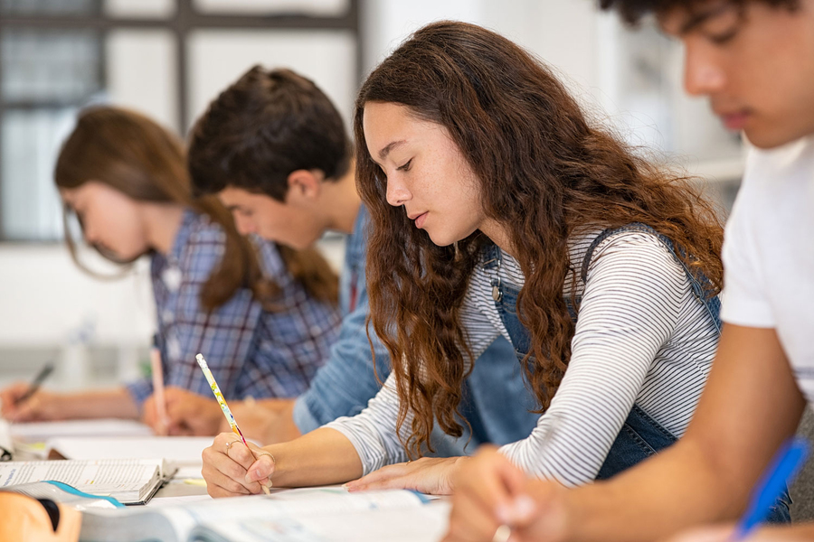

_

## Sobre el dataset

Esta base de datos proporciona una descripción general completa de varios factores que afectan el desempeño de los estudiantes en los exámenes. Incluye información sobre hábitos de estudio, asistencia, participación de los padres y otros aspectos que influyen en el éxito académico.

## Variables

```
 [1] "Sexo"                          "Horas_estudio"
 [3] "Porcentaje_asistencia"         "Nota_previa"
 [5] "Acceso_internet"               "Horas_sueño"
 [7] "Actividad_fisica"              "Ingreso_familiar"
 [9] "Tipo_escuela"                  "Hace_tutorias"
[11] "Num_tutorias"                  "Actividades_extracurriculares"
[13] "Nota_examen"
```

## Consigna 1

### Defina la población bajo estudio y la muestra.

Población: todos los estudiantes de secundaria del mundo

Muestra: los 6607 estudiantes de la base de datos

## Aclaración

Para todas las consignas de planteo de hipótesis, decidimos usar un alpha = 0,05

## Consigna 2

### El promedio de horas de estudio de los estudiantes, ¿es mayor a 15 horas semanales?

```
El promedio de horas de estudio es: 19.98
```

```
El promedio de horas de estudio es mayor a 15 horas semanales.
```

## Consigna 3

### ¿Existen diferencias en las horas de estudio promedio entre hombres y mujeres?

$$H_0: \; \mu_{\text{horas_de_estudio_hombres}} \; = \;
\mu_{\text{horas_de_estudio_mujeres}}$$

$$H_1: \; \mu_{\text{horas_de_estudio_hombres}} \; \neq \;
\mu_{\text{horas_de_estudio_mujeres}}$$

```
El promedio de horas de estudio del sexo femenino es: 20.0050125313283
```

```
El promedio de horas de estudio del sexo masculino es: 19.9535920293655
```

```
Valor p de la prueba t: 0.730452293733073
```

```
No existen diferencias significativas en las horas de estudio entre hombres y mujeres.
```

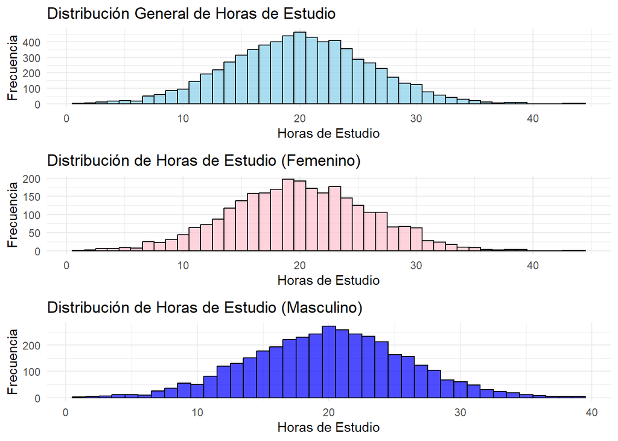

## Consigna 4

### ¿Cuál es la proporción de estudiantes que tienen acceso a internet en casa?

### ¿Es superior al 90%?

```
La proporción de estudiantes con acceso a internet en sus casas es: 0.924474042682004
```

```
La proporción es superior al 90%.
```

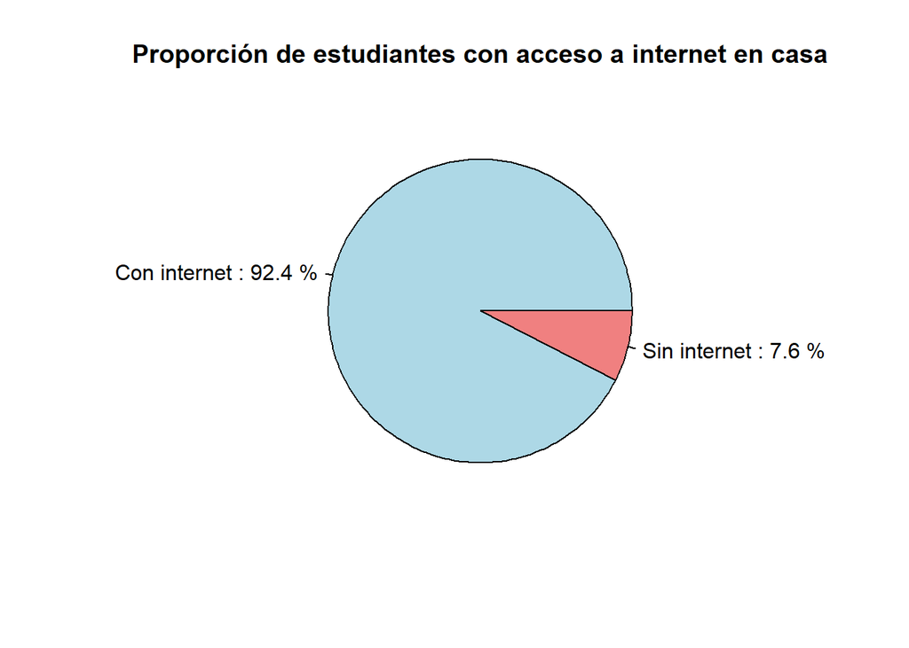

## Consigna 5

### Desde secretaría estudiantil afirman que tres de cada cuatro alumnos asisten a tutorías ¿Es correcta esta afirmación? ¿Difiere la proporción de alumnos que asisten a tutorías según el sexo?

$$H_0: \text{proporción masculina de alumnos que realizan tutorías} =
\text{proporción femenina de alumnos que realizan tutorías}$$

$$H_1: \text{proporción masculina de alumnos que realizan tutorías} \neq
\text{proporción femenina de alumnos que realizan tutorías}$$

```
La proporción de estudiantes que realizan tutorías es: 0.771000454063872
```

```
La proporción de estudiantes que realizan tutorías de sexo femenino es: 0.423046721633294
```

```
La proporción de estudiantes que realizan turorias de sexo masculino es: 0.576953278366706
```

```
¿La afirmación de que tres de cada cuatro estudiantes asisten a tutorías es correcta?: Sí
```

```
Valor p de la prueba de hipótesis: 0.00000000000000000000000000000000000000000000000000000275321949207515
```

```
¿La diferencia en la proporción de asistencia a tutorías entre hombres y mujeres es significativa?: Sí
```

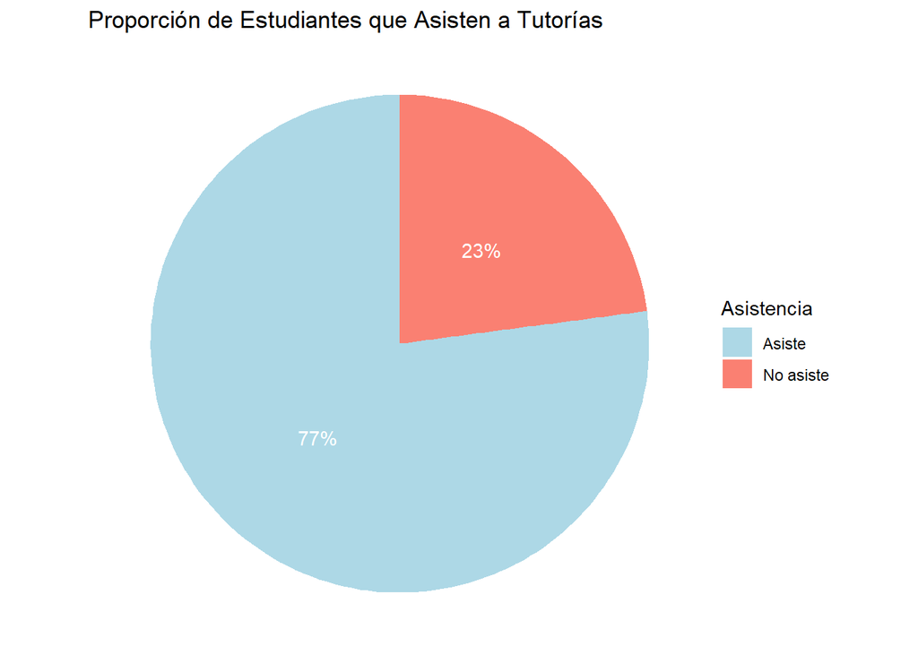

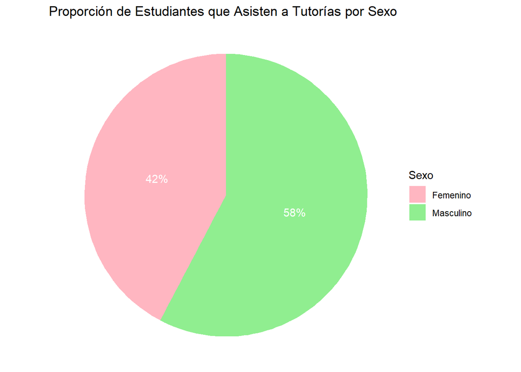

## Consigna 6

### La calificación promedio de los estudiantes, ¿es distinta según si tienen o no acceso a internet? ¿Difiere entre quienes hacen actividades extracurriculares y quienes no?

$$\text{1er conjunto de hipótesis}$$

$$H_0: \; \mu_{\text{estudiantes_con_internet}} \; = \;
\mu_{\text{estudiantes_sin_internet}}$$

$$H_1: \; \mu_{\text{estudiantes_con_internet}} \; \neq \;
\mu_{\text{estudiantes_sin_internet}}$$
$$\text{2do conjunto de hipótesis}$$

$$H_0: \; \mu_{\text{estudiantes_con_extracurriculares}} \; = \;
\mu_{\text{estudiantes_sin_extracurriculares}}$$

$$H_1: \; \mu_{\text{estudiantes_con_extracurriculares}} \; \neq \;
\mu_{\text{estudiantes_sin_extracurriculares}}$$

```
El promedio de calificación de los estudiantes con acceso a internet es: 67.2928945645056
```

```
El promedio de calificación de los estudiantes sin acceso a internet es: 66.5350701402806
```

```
El promedio de calificación de los estudiantes que hacen actividades extracurriculares es: 67.4418486541392
```

```
El promedio de calificación de los estudiantes que no hacen actividades extracurriculares es: 66.9314349943799
```

```
Valor p de la prueba t para acceso a internet: 0.0000814090121081913
```

```
Existen diferencias significativas en las calificaciones según acceso a internet.
```

```
Valor p de la prueba t para actividades extracurriculares: 0.000000131919676838137
```

```
Existen diferencias significativas en las calificaciones entre estudiantes que hacen actividades extracurriculares y los que no.
```

## Consigna 7

### Comente acerca de la representatividad de la muestra utilizada, ¿tiene alguna crítica o comentario acerca de la veracidad de los resultados?

[figure not shown]

_

## Hipótesis extra

$$H_0: \rho_\text{nota previa; nota examen} \in [-0,1; 0,1]$$

$$H_1: \rho_\text{nota previa; nota examen} \in [-1; -0,1) \cup (0,1; 1]$$

```
    Pearson's product-moment correlation

data:  estudiantes$Nota_previa and estudiantes$Nota_examen
t = 14.452, df = 6605, p-value < 0.00000000000000022
alternative hypothesis: true correlation is not equal to 0
95 percent confidence interval:
 0.1516056 0.1983552
sample estimates:
      cor
0.1750791
```

```
Valor p: 0.000000000000000000000000000000000000000000000124438
```

```
Rechazamos la hipótesis nula: existe una correlación significativa entre la Nota previa y la Nota de examen.
```

```
La correlación es débil (positiva).
```

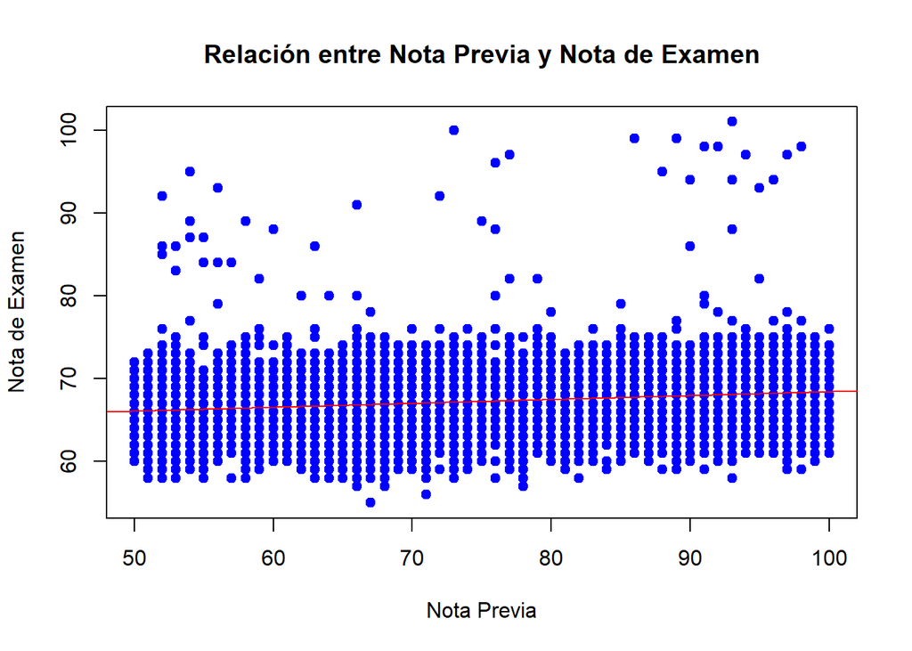